# R Notebook

Q1) Preliminaries

```r
assignment5 = read_csv("assignment5_data.csv")
```

Q2) Subject-level means

```r
subject_rt = assignment5 %>%
  group_by(subject, prime_condition) %>%
  summarise(mean_rt = mean(response_RT))
```

Q3) Format of the data Both subject_accuracy and subject_rt are in long format.

Q4) Long to wide conversion

Q5) Wide to long conversion

Q6) Interpretation The subject_accuracy dataframe contains the same information as subject_accuracy_long.

```r
t.test(subject_accuracy_wide$phonological, subject_accuracy_wide$semantic, var.equal = TRUE, paired = TRUE)
```

```
    Paired t-test

data:  subject_accuracy_wide$phonological and subject_accuracy_wide$semantic
t = 4.4075, df = 36, p-value = 9.033e-05
alternative hypothesis: true mean difference is not equal to 0
95 percent confidence interval:
 0.0706192 0.1910024
sample estimates:
mean difference
      0.1308108
```

Q8) t-test interpretation The p-value (0.00009033) is smaller than the alpha (0.05), so the results from the study are statistically significant. We can reject the null hypothesis.

Q9) t-test manual

```r
subject_accuracy_wide = subject_accuracy_wide %>%
  mutate(diff = phonological - semantic)

x_bar = mean(subject_accuracy_wide$diff)
sd_diff = sd(subject_accuracy_wide$diff)
t = x_bar/(sd_diff/sqrt(nrow(subject_accuracy_wide)))

df = nrow(subject_accuracy_wide)-1

p_value = 2*(1-pt(t,df))
```

Q10) t-test outliers

Q11) t-test normality

| variable | statistic | p |
| --- | --- | --- |
| diff | 0.9787041 | 0.6864971 |

The normality assumption is satisfied because p is larger than 0.05 (0.686)

Q12) Overall pattern interpretation

The test of assumptions does not change my conclusion about the validity of the t-test. The type of cue that is given to people impacts their ability to retrieve words from memory. Specifically, people are more accurate when retrieving words phonologically compared to semantically.

Q13) Plot rts

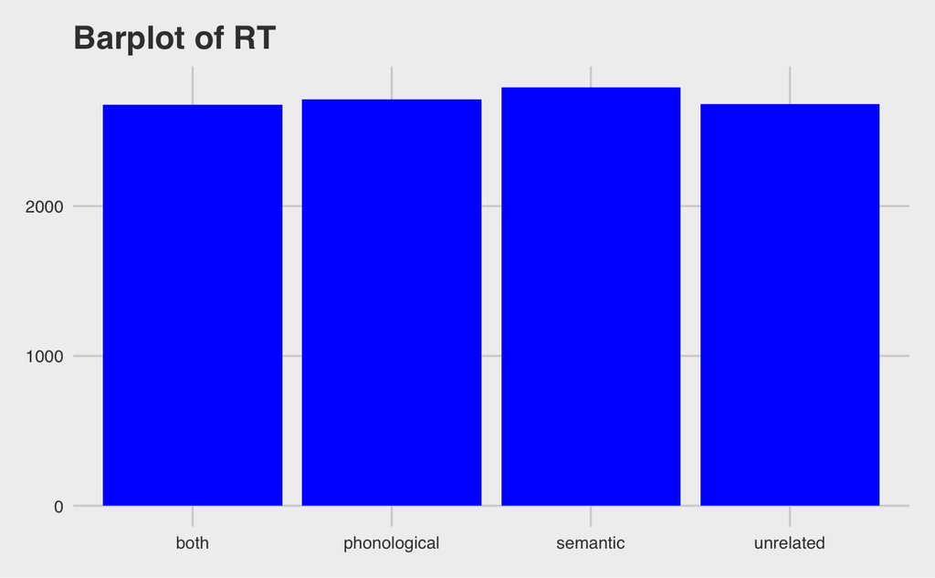

14. t-test for RTs

[output not shown]